# Traffic_Sign_Classifier

```python
import numpy as np
import pandas as pd
import matplotlib.pyplot as plt
import tensorflow as tf
import cv2
from sklearn.utils import shuffle
from keras.preprocessing.image import ImageDataGenerator
from tensorflow.contrib.layers import flatten
import collections
```

```python
tf.__version__
```

```
'1.3.0'
```

## Step 0: Load The Data

```python
# Load pickled data
import pickle

training_file = './data/train.p'
validation_file= './data/valid.p'
testing_file = './data/test.p'

with open(training_file, mode='rb') as f:  # r: read, b: binary mode
    train = pickle.load(f)
with open(validation_file, mode='rb') as f:
    valid = pickle.load(f)
with open(testing_file, mode='rb') as f:
    test = pickle.load(f)

X_train, y_train = train['features'], train['labels']
X_valid, y_valid = valid['features'], valid['labels']
X_test, y_test = test['features'], test['labels']
```

## Step 1: Dataset Summary & Exploration

The pickled data is a dictionary with 4 key/value pairs:

- `'features'` is a 4D array containing raw pixel data of the traffic sign images, (num examples, width, height, channels).
- `'labels'` is a 1D array containing the label/class id of the traffic sign. The file `signnames.csv` contains id -> name mappings for each id.
- `'sizes'` is a list containing tuples, (width, height) representing the original width and height the image.
- `'coords'` is a list containing tuples, (x1, y1, x2, y2) representing coordinates of a bounding box around the sign in the image. **THESE COORDINATES ASSUME THE ORIGINAL IMAGE. THE PICKLED DATA CONTAINS RESIZED VERSIONS (32 by 32) OF THESE IMAGES**

### Provide a Basic Summary of the Data Set Using Python, Numpy and/or Pandas

```python
# Number of training examples
n_train = len(X_train)

# Number of validation examples
n_validation = len(X_valid)

# Number of testing examples.
n_test = len(X_test)

# Image shape
image_shape = X_train[0].shape

# Number of classes
n_classes = len(np.unique(y_train))

print("Number of training examples =", n_train)
print("Number of testing examples =", n_test)
print("Image data shape =", image_shape)
print("Number of classes =", n_classes)
```

```
Number of training examples = 34799
Number of testing examples = 12630
Image data shape = (32, 32, 3)
Number of classes = 43
```

### Include an exploratory visualization of the dataset

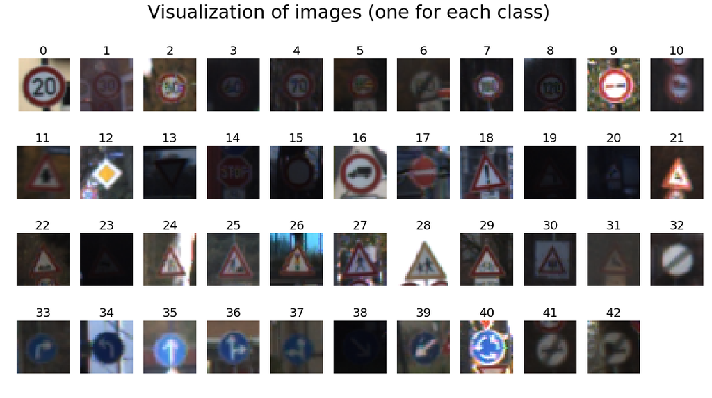

```python
# Visualize one image for each class
labels, index = np.unique(y_train, return_index=True)
fig, axes = plt.subplots(4,11, figsize=(20,10))
plt.suptitle('Visualization of images (one for each class)', fontsize=30)
ax = [a for a in axes.ravel()]
for i, j in enumerate(index):
      ax[i].imshow(X_train[j].squeeze())
      ax[i].set_title(y_train[j], fontsize=20)
      ax[i].axis('off')
ax[-1].axis('off')
plt.savefig('./output_images/Visualization_xtrain.jpg')
```

```python
# Read the csv file
signname = pd.read_csv('./signnames.csv')
signname.head()
```

|  | ClassId | SignName |
| --- | --- | --- |
| 0 | 0 | Speed limit (20km/h) |
| 1 | 1 | Speed limit (30km/h) |
| 2 | 2 | Speed limit (50km/h) |
| 3 | 3 | Speed limit (60km/h) |
| 4 | 4 | Speed limit (70km/h) |

```python
# Calculate the number of images for each class
y_train_freq = np.zeros(n_classes)
y_valid_freq = np.zeros(n_classes)
y_test_freq = np.zeros(n_classes)
for num in range(n_classes):
    y_train_freq[num] = np.sum(y_train == num)/n_train
    y_valid_freq[num] = np.sum(y_valid == num)/n_validation
    y_test_freq[num] = np.sum(y_test == num)/n_test
```

```python
# Add the above result into the csv file
signname['Training proportion'] = y_train_freq # The proportion of training images for each class
signname['Validation proportion'] = y_valid_freq # The proportion of validation images for each class
signname['Test proportion'] = y_test_freq # The proportion of test images for each class
signname.head()
```

|  | ClassId | SignName | Training proportion | Validation proportion | Test proportion |
| --- | --- | --- | --- | --- | --- |
| 0 | 0 | Speed limit (20km/h) | 0.005173 | 0.006803 | 0.004751 |
| 1 | 1 | Speed limit (30km/h) | 0.056898 | 0.054422 | 0.057007 |
| 2 | 2 | Speed limit (50km/h) | 0.057760 | 0.054422 | 0.059382 |
| 3 | 3 | Speed limit (60km/h) | 0.036208 | 0.034014 | 0.035629 |
| 4 | 4 | Speed limit (70km/h) | 0.050864 | 0.047619 | 0.052257 |

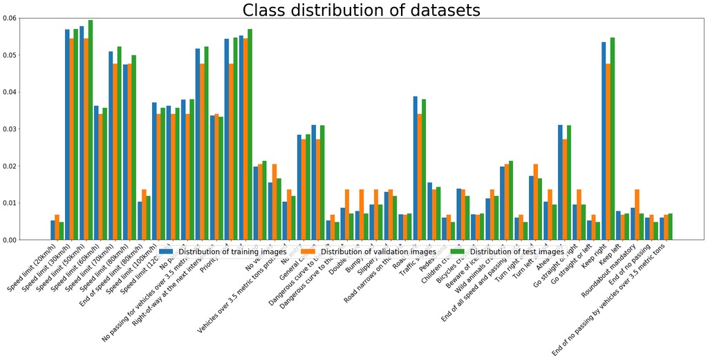

```python
names = signname['SignName'].values
x = np.arange(len(names))
w = 0.3
plt.title('Class distribution of datasets', fontsize=40)
plt.rcParams['figure.figsize'] = (30,10)
plt.bar(x-w, signname['Training proportion'].values, width=w, label='Distribution of training images')
plt.bar(x, signname['Validation proportion'].values, width=w, label='Distribution of validation images')
plt.bar(x+w, signname['Test proportion'].values, width=w, label='Distribution of test images')

plt.xticks(x, names, horizontalalignment='right', rotation=45, size=15)
plt.ylim([0,0.06])
plt.yticks(size=15)
# plt.tight_layout()
plt.legend(loc=8, bbox_to_anchor=(0.5, -0.1), fancybox=True, ncol=3, fontsize='xx-large')
plt.savefig('./output_images/CSVBarplots.png', bbox_inches="tight")
plt.show()
```

## Step 2: Design and Test a Model Architecture

Design and implement a deep learning model that learns to recognize traffic signs. Train and test your model on the [German Traffic Sign Dataset](http://benchmark.ini.rub.de/?section=gtsrb&subsection=dataset).

### Pre-process the Data Set (normalization, grayscale, etc.)

```python
# Normalize the data
def normalize(image):
    norm = (image-image.mean())/(image.std() + 1e-8)
    return norm

# Converte it to grayscale
def grayscale(image):
    return cv2.cvtColor(image, cv2.COLOR_RGB2GRAY)

def preprocess(X):
    X_new = []
    for idx, image in enumerate(X):
        img = grayscale(image)
        img = normalize(img)
        X_new.append(img)

    return np.expand_dims(np.array(X_new), axis=-1)
```

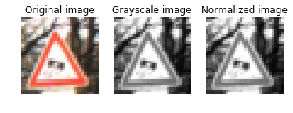

```python
gray = grayscale(X_train[2030])
norm_gray = normalize(gray)
fig, axes = plt.subplots(1,3)
axes[0].imshow(X_train[2030])
axes[0].set_title('Original image')
axes[0].axis('off')
axes[1].imshow(gray, cmap='gray')
axes[1].set_title('Grayscale image')
axes[1].axis('off')
axes[2].imshow(norm_gray, cmap='gray')
axes[2].set_title('Normalized image')
axes[2].axis('off')
plt.savefig('./output_images/gray.jpg', bbox_inches="tight")
```

```python
# Preprocess the dataset
X_train_norm = preprocess(X_train)
X_valid_norm = preprocess(X_valid)
X_test_norm = preprocess(X_test)
```

```python
# Shuffle the dataset
X_train_norm, y_train = shuffle(X_train_norm, y_train)
X_valid_norm, y_valid = shuffle(X_valid_norm, y_valid)
```

```python
# Apply data augmentation
def my_image_augmentation():
    idg = ImageDataGenerator( horizontal_flip = False,
                              vertical_flip = False,
                              height_shift_range = 0.1,
                              width_shift_range = 0.1,
                              rotation_range = 20,
                              shear_range = 0.1,
                              zoom_range= 0.2
                              )
    return idg
```

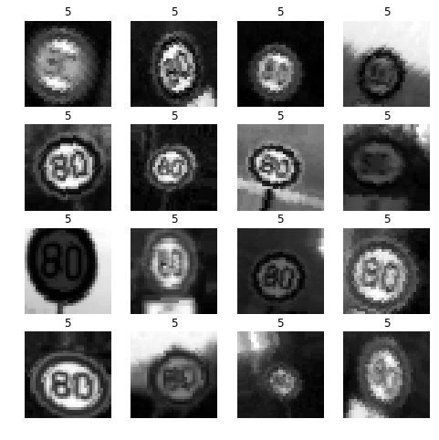

```python
# Plot the augmented images of class 5
t_x, t_y = my_image_augmentation().flow(X_train_norm, y_train, batch_size=1000).next()
fig, axes = plt.subplots(4, 4, figsize = (8,8))
aug_imgs=[]
for cx, cy in zip(t_x, t_y):
        if cy == 5:
            aug_imgs.append(cx)
        if len(aug_imgs) == 16:
            break
for i, ax in enumerate(axes.flatten()):
    ax.imshow(aug_imgs[i][:,:,0], cmap = 'gray')
    ax.set_title(5)
    ax.axis('off')
plt.savefig('./output_images/augment.jpg', bbox_inches="tight")
```

### Model Architecture

```python
def conv2d(x, W, B, stride, pad):
    conv = tf.nn.conv2d(x, W, strides=[1,stride, stride,1], padding=pad)
    conv = tf.nn.bias_add(conv, B)
    return conv

def max_pool(x, k, stride, pad):
    return tf.nn.max_pool(x, ksize=[1,k,k,1], strides=[1,stride,stride,1], padding=pad)

def LeNet(x):
    mu = 0
    sigma = 0.1

    # Layer 1. Convolutional. Input = 32x32x1, Output = 28x28x6
    # [(32 - f +2p)/s] + 1 = 28. p=0, s=1, f=5
    wc1 = tf.Variable(tf.truncated_normal([5, 5, 1, 6], mean = mu, stddev = sigma), name='wc1_weight')
    bc1 = tf.Variable(tf.zeros(6), name='bc1')
    conv1 = conv2d(x, wc1, bc1, stride=1, pad='VALID')
    # Activation
    conv1 = tf.nn.relu(conv1)
    # Max pooling. Input = 28x28x6, Output = 14x14x6
    # [(28 - k)/s] + 1 = 14. s=2, k=2
    conv1 = max_pool(conv1, k=2, stride=2, pad='VALID')

    # Layer 2. Convolutional. Input = 14x14x6, Output = 10x10x16
    # [(14 - f + 2p)/s] + 1 = 10. s=1, p=0, f=5
    wc2 = tf.Variable(tf.truncated_normal([5, 5, 6, 16], mean = mu, stddev = sigma), name='wc2_weight')
    bc2 = tf.Variable(tf.zeros(16), name='bc2')
    conv2 = conv2d(conv1, wc2, bc2, stride=1, pad='VALID')
    # Activation
    conv2 = tf.nn.relu(conv2)
    # Max pooling. Input = 10x10x16, Output = 5x5x16
    # [(10 - k)/s] + 1 = 5. s=2, k=2
    conv2 = max_pool(conv2, k=2, stride=2, pad='VALID')

    # Flatten. Input = 5x5x16. Output = 400
    fc0 = flatten(conv2)

    # Layer 3. Fully connected. Input = 400, Output = 120
    wd1 = tf.Variable(tf.truncated_normal([400, 120], mean = mu, stddev = sigma), name='wd1_weight')
    bd1 = tf.Variable(tf.zeros(120), name='bd1')
    fc1 = tf.add(tf.matmul(fc0, wd1), bd1)
    # Activation
    fc1 = tf.nn.relu(fc1)
    # Dropout
    fc1 = tf.nn.dropout(fc1, keep_prob)

    # Layer 4. Fully connected. Input = 120, Output = 84
    wd2 = tf.Variable(tf.truncated_normal([120, 84], mean = mu, stddev = sigma), name='wd2_weight')
    bd2 = tf.Variable(tf.zeros(84), name='bd2')
    fc2 = tf.add(tf.matmul(fc1, wd2), bd2)
    # Activation
    fc2 = tf.nn.relu(fc2)
    # Dropout
    fc2 = tf.nn.dropout(fc2, keep_prob)

    # Layer 5. Fully connected. Input = 84, Output = 43
    wd3 = tf.Variable(tf.truncated_normal([84, 43], mean = mu, stddev = sigma), name='wd3_weight')
    bd3 = tf.Variable(tf.zeros(43), name='bd3')
    logits = tf.add(tf.matmul(fc2, wd3), bd3)

    return logits
```

### Train, Validate and Test the Model

```python
# Hyperparameters
rate = 0.001
EPOCHS = 100
BATCH_SIZE = 128
```

```python
train_gen = my_image_augmentation().flow(X_train_norm, y_train, batch_size=BATCH_SIZE)
```

```python
# Define features
x = tf.placeholder(dtype=tf.float32, shape=(None, 32, 32, 1))
y = tf.placeholder(dtype=tf.int32, shape=(None))
one_hot_y = tf.one_hot(y, n_classes)
keep_prob = tf.placeholder(dtype=tf.float32)
```

```python
logits = LeNet(x)
l2_lambda = 0.0001
cross_entropy = tf.nn.softmax_cross_entropy_with_logits(labels=one_hot_y, logits=logits)
l2_term = l2_lambda * tf.reduce_sum([tf.nn.l2_loss(t) for t in tf.trainable_variables() if 'weight' in t.name])
cross_entropy_l2 = cross_entropy + l2_term
loss_operation = tf.reduce_mean(cross_entropy_l2)
optimizer = tf.train.AdamOptimizer(learning_rate = rate)
training_operation = optimizer.minimize(loss_operation)
```

```python
# Early Stopping
class EarlyStopping():
    def __init__(self):
        self.patience = 10
        self.best_acc = 0
        self.current_acc = None
        self.num_earlystopping = collections.deque(maxlen=self.patience)

    def update_acc(self, accuracy):
        self.current_acc = accuracy
        if self.current_acc > self.best_acc:
            self.best_acc = self.current_acc
        else:
            self.best_acc = self.best_acc

    def update_num(self, accuracy):
        if self.best_acc >= accuracy:
            self.num_earlystopping.append(1)
        else:
            self.num_earlystopping.append(0)

    def reset_state(self):
        self.current_acc = None
        self.num_earlystopping = collections.deque(maxlen=self.patience)
```

```python
# Store the accuracy for each epoch
class Accuracy():
    def __init__(self):
        self.acc = []

    def update_acc(self, accuracy):
        self.acc.append(accuracy)

    def reset_state(self):
        self.acc = []

# Store the loss for each epoch
class Loss():
    def __init__(self):
        self.loss = []

    def update_loss(self, loss):
        self.loss.append(loss)

    def reset_state(self):
        self.loss = []
```

```python
# Store y_pred and y_true to calculate confusion matrix
class pred_true():
    def __init__(self):
        self.prediction = None
        self.groundtruth = None

    def update_state(self, y_true, y_pred):
        if self.prediction is None:
            self.prediction = y_pred
        if self.groundtruth is None:
            self.groundtruth = y_true
        else:
            self.prediction = np.concatenate((self.prediction, y_pred), axis=0)
            self.groundtruth = np.concatenate((self.groundtruth, y_true), axis=0)

    def reset_states(self):
        self.prediction = None
        self.groundtruth = None
```

```python
stop = EarlyStopping()
```

```python
acc_train = Accuracy()
acc_valid = Accuracy()
loss_train = Loss()
loss_valid = Loss()
```

```python
pt = pred_true()
```

```python
y_pred = tf.argmax(logits, 1)
y_true = tf.argmax(one_hot_y, 1)
correct_prediction = tf.equal(y_pred, y_true)
accuracy_operation = tf.reduce_mean(tf.cast(correct_prediction, tf.float32))
saver = tf.train.Saver()


def evaluate(X_data, y_data, test=False):
    num_examples = len(X_data)
    total_accuracy = 0
    total_loss = 0
    sess = tf.get_default_session()
    if test == True:
        for offset in range(0, num_examples, BATCH_SIZE):
            batch_x, batch_y = X_data[offset:offset+BATCH_SIZE], y_data[offset:offset+BATCH_SIZE]
            accuracy, loss, prediction, groundtruth = sess.run([accuracy_operation, loss_operation, y_pred, y_true], feed_dict={x: batch_x, y: batch_y, keep_prob: 0.75})
            pt.update_state(groundtruth, prediction)
            total_accuracy += (accuracy * len(batch_x))
            total_loss += (loss * len(batch_x))
        pred, true = pt.prediction, pt.groundtruth
        pt.reset_states
        return total_accuracy / num_examples, total_loss/num_examples, pred, true

    else:
        for offset in range(0, num_examples, BATCH_SIZE):
            batch_x, batch_y = X_data[offset:offset+BATCH_SIZE], y_data[offset:offset+BATCH_SIZE]
            accuracy, loss = sess.run([accuracy_operation, loss_operation], feed_dict={x: batch_x, y: batch_y, keep_prob: 0.75})
            total_accuracy += (accuracy * len(batch_x))
            total_loss += (loss * len(batch_x))
        return total_accuracy / num_examples, total_loss/num_examples
```

```python
with tf.Session() as sess:
    sess.run(tf.global_variables_initializer())
    num_examples = len(X_train_norm)

    print("Training...")
    print()
    for i in range(EPOCHS):
        train_iters = 0
        print("EPOCH {} ...".format(i+1))
        for batch_x, batch_y in train_gen:
            train_iters += 1
            sess.run(training_operation, feed_dict={x: batch_x, y: batch_y, keep_prob: 0.75})
            # An epoch is completed
            if train_iters == num_examples//BATCH_SIZE:
                break
        training_accuracy, training_loss = evaluate(X_train_norm, y_train, test=False)
        validation_accuracy, validation_loss = evaluate(X_valid_norm, y_valid, test=False)
        stop.update_num(validation_accuracy)
        stop.update_acc(validation_accuracy)
        acc_train.update_acc(training_accuracy)
        acc_valid.update_acc(validation_accuracy)
        loss_train.update_loss(training_loss)
        loss_valid.update_loss(validation_loss)
        print("Training Accuracy = {:.3f}, Training Loss = {:.3f}".format(training_accuracy, training_loss))
        print("Validation Accuracy = {:.3f}, Validation Loss = {:.3f}".format(validation_accuracy, validation_loss))
        print()
        if np.sum(stop.num_earlystopping) >= 10:
            print('Early Stopping at epoch {}.'.format(i))
            stop.reset_state()
            train_acc = acc_train.acc
            valid_acc = acc_valid.acc
            train_losses = loss_train.loss
            valid_losses = loss_valid.loss
            acc_train.reset_state()
            acc_valid.reset_state()
            loss_train.reset_state()
            loss_valid.reset_state()
            break
    saver.save(sess, './lenet')
    print("Model saved")
```

```
Training...

EPOCH 1 ...
Training Accuracy = 0.442, Training Loss = 1.899
Validation Accuracy = 0.428, Validation Loss = 2.059

EPOCH 2 ...
Training Accuracy = 0.646, Training Loss = 1.153
Validation Accuracy = 0.603, Validation Loss = 1.314

EPOCH 3 ...
Training Accuracy = 0.737, Training Loss = 0.856
Validation Accuracy = 0.690, Validation Loss = 1.033

EPOCH 4 ...
Training Accuracy = 0.800, Training Loss = 0.683
Validation Accuracy = 0.741, Validation Loss = 0.866

EPOCH 5 ...
Training Accuracy = 0.829, Training Loss = 0.588
Validation Accuracy = 0.769, Validation Loss = 0.764

EPOCH 6 ...
Training Accuracy = 0.853, Training Loss = 0.520
Validation Accuracy = 0.792, Validation Loss = 0.688

EPOCH 7 ...
Training Accuracy = 0.869, Training Loss = 0.459
Validation Accuracy = 0.815, Validation Loss = 0.623

EPOCH 8 ...
Training Accuracy = 0.886, Training Loss = 0.408
Validation Accuracy = 0.825, Validation Loss = 0.597

EPOCH 9 ...
Training Accuracy = 0.900, Training Loss = 0.368
Validation Accuracy = 0.842, Validation Loss = 0.547

EPOCH 10 ...
Training Accuracy = 0.908, Training Loss = 0.342
```

[output cut: 197 more lines]

```

EPOCH 60 ...
Training Accuracy = 0.978, Training Loss = 0.145
Validation Accuracy = 0.942, Validation Loss = 0.285

EPOCH 61 ...
Training Accuracy = 0.979, Training Loss = 0.144
Validation Accuracy = 0.936, Validation Loss = 0.287

EPOCH 62 ...
Training Accuracy = 0.980, Training Loss = 0.141
Validation Accuracy = 0.937, Validation Loss = 0.276

Early Stopping at epoch 61.
Model saved
```

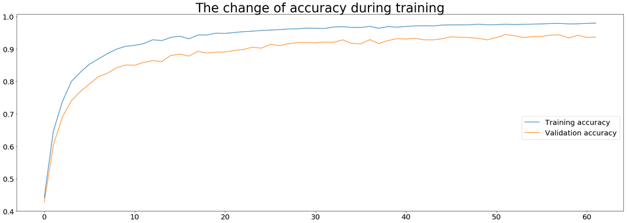

```python
plt.plot(train_acc, label="Training accuracy")
plt.plot(valid_acc, label="Validation accuracy")
plt.title('The change of accuracy during training', fontsize=35)
plt.xticks(size=20)
plt.yticks(size=20)
plt.legend(bbox_to_anchor=(1, 0.5), loc=0, borderaxespad=0.5, prop={'size': 20})
plt.savefig('./output_images/accuracy_train.jpg', bbox_inches="tight")
plt.show()
```

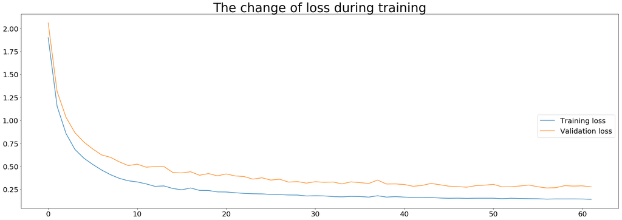

```python
plt.plot(train_losses, label="Training loss")
plt.plot(valid_losses, label="Validation loss")
plt.title('The change of loss during training', fontsize=35)
plt.xticks(size=20)
plt.yticks(size=20)
plt.legend(bbox_to_anchor=(1, 0.5), loc=0, borderaxespad=0.5, prop={'size': 20})
plt.savefig('./output_images/loss_train.jpg', bbox_inches="tight")
plt.show()
```

```python
import pandas

mylist = [train_acc, valid_acc, train_losses, valid_losses]
rows = ['train_acc', 'valid_acc', 'train_losses', 'valid_losses']
pd = pandas.DataFrame(mylist, index=rows)
pd.to_csv("mylist.csv")
pd
```

|  | 0 | 1 | 2 | 3 | 4 | 5 | 6 | 7 | 8 | 9 | ... | 52 | 53 | 54 | 55 | 56 | 57 | 58 | 59 | 60 | 61 |
| --- | --- | --- | --- | --- | --- | --- | --- | --- | --- | --- | --- | --- | --- | --- | --- | --- | --- | --- | --- | --- | --- |
| train_acc | 0.442427 | 0.646197 | 0.737435 | 0.799879 | 0.828558 | 0.853070 | 0.869393 | 0.885945 | 0.899537 | 0.908331 | ... | 0.975114 | 0.976034 | 0.976666 | 0.977298 | 0.978333 | 0.978850 | 0.977241 | 0.977614 | 0.978907 | 0.979655 |
| valid_acc | 0.428118 | 0.603401 | 0.690023 | 0.740590 | 0.769161 | 0.792063 | 0.814739 | 0.825397 | 0.842177 | 0.850567 | ... | 0.940816 | 0.935147 | 0.937868 | 0.938549 | 0.942857 | 0.943537 | 0.933787 | 0.942404 | 0.935601 | 0.936508 |
| train_losses | 1.899269 | 1.152897 | 0.856414 | 0.683476 | 0.588315 | 0.520194 | 0.459351 | 0.408270 | 0.368380 | 0.342267 | ... | 0.152063 | 0.149556 | 0.147538 | 0.146888 | 0.142727 | 0.145076 | 0.144791 | 0.145113 | 0.143973 | 0.140653 |
| valid_losses | 2.059406 | 1.314173 | 1.032815 | 0.865748 | 0.763922 | 0.688160 | 0.623198 | 0.597207 | 0.547138 | 0.507576 | ... | 0.277081 | 0.285827 | 0.296046 | 0.277299 | 0.263914 | 0.267343 | 0.288898 | 0.284781 | 0.287089 | 0.276180 |

4 rows × 62 columns

```python
with tf.Session() as sess:
    saver.restore(sess, tf.train.latest_checkpoint('.'))

    test_accuracy, test_loss, pred, true = evaluate(X_test_norm, y_test, test=True)
    print("Test Accuracy = {:.3f}, Test Loss = {:.3f}".format(test_accuracy, test_loss))
```

```
INFO:tensorflow:Restoring parameters from ./lenet
Test Accuracy = 0.928, Test Loss = 0.375
```

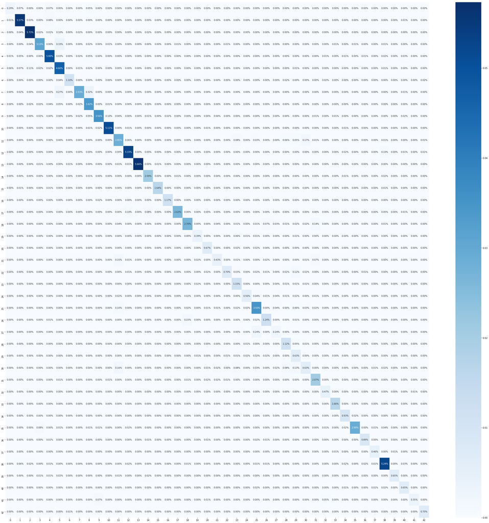

```python
import seaborn as sn
from sklearn import metrics
import matplotlib.pyplot as plt
cm=metrics.confusion_matrix(true, pred)
plt.figure(figsize = (43,43))
sn.heatmap(cm/np.sum(cm), annot=True,
            fmt='.2%', cmap='Blues')
```

## Step 3: Test a Model on New Images

To give yourself more insight into how your model is working, download at least five pictures of German traffic signs from the web and use your model to predict the traffic sign type.

You may find `signnames.csv` useful as it contains mappings from the class id (integer) to the actual sign name.

### Load and Output the Images

```python
import os
import glob
import matplotlib.image as mpimg
# Imaged were loaded from GTSRB_Final_Test_Images
new_images_path = sorted(glob.glob('./new_images/*'))
new_labels = np.array([16,1,38,33,11,38])
```

```python
import cv2
new_images = []
for path in new_images_path:
    img = cv2.imread(path)
    res = cv2.resize(img, dsize=(32,32), interpolation=cv2.INTER_CUBIC)
    new_images.append(res)
```

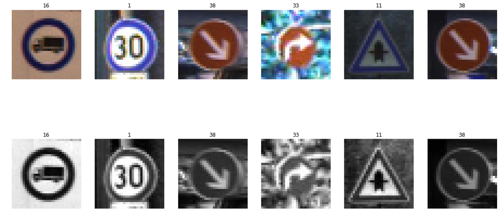

```python
new_images_norm = preprocess(new_images)
fig, axes = plt.subplots(2,6, figsize=(20,10))
for num, image in enumerate(new_images):
    axes[0,num].imshow(image)
    axes[0,num].set_title(new_labels[num])
    axes[0,num].axis('off')
    axes[1,num].imshow(new_images_norm[num][:,:,0], cmap='gray')
    axes[1,num].set_title(new_labels[num])
    axes[1,num].axis('off')
plt.savefig('./output_images/new_images.jpg', bbox_inches="tight")
```

### Predict the Sign Type for Each Image

```python
predictions = []

with tf.Session() as sess:
    saver.restore(sess, './lenet')
    predictions = sess.run(y_pred, feed_dict={x: new_images_norm, y: new_labels, keep_prob: 0.75})

print(f"Predictions = {predictions}")
print(f"Actual = {new_labels}")
```

```
INFO:tensorflow:Restoring parameters from ./lenet
Predictions = [16  1 38 33 11 38]
Actual = [16  1 38 33 11 38]
```

### Analyze Performance

```python
def cal_accuracy(y_pred, y_true):
    accuracy = np.sum(y_pred == y_true)/len(y_true)*100
    return accuracy
accuracy = cal_accuracy(predictions, new_labels)
print(f"Accuracy = {accuracy:.2f}%")
```

```
Accuracy = 100.00%
```

```python
with tf.Session() as sess:
    saver.restore(sess, tf.train.latest_checkpoint('.'))

    new_accuracy, new_loss, pred, true = evaluate(new_images_norm, new_labels, test=True)
    print("Test Accuracy = {:.3f}, Test Loss = {:.3f}".format(new_accuracy, new_loss))
```

```
INFO:tensorflow:Restoring parameters from ./lenet
Test Accuracy = 1.000, Test Loss = 0.070
```

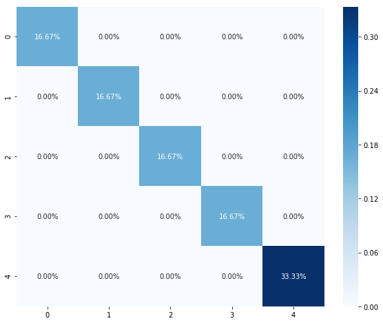

```python
new_cm=metrics.confusion_matrix(new_labels, predictions)
plt.figure(figsize = (10,8))
sn.heatmap(new_cm/np.sum(new_cm), annot=True,
            fmt='.2%', cmap='Blues')
plt.savefig('./output_images/new_images_cm.jpg', bbox_inches="tight")
```

### Output Top 5 Softmax Probabilities For Each Image Found on the Web

```python
predictions = np.zeros((len(new_images_norm), n_classes))
with tf.Session() as sess:
    saver.restore(sess, './lenet')
    predictions = sess.run(tf.nn.softmax(logits), feed_dict={x: new_images_norm, y: new_labels, keep_prob: 0.75})
    result = sess.run(tf.nn.top_k(tf.constant(predictions), k=5), feed_dict={x: new_images_norm, y: new_labels, keep_prob: 0.75})

for i in range(6):
    print(f"Top 5 Probabilities of image {i} (True label is {new_labels[i]})")
    for j in range(5):
        print(f"Top {j+1} prediction is class {result[1][i][j]} with confidence = {result[0][i][j]:.2f}")
```

```
INFO:tensorflow:Restoring parameters from ./lenet
Top 5 Probabilities of image 0 (True label is 16)
Top 1 prediction is class 16 with confidence = 1.00
Top 2 prediction is class 9 with confidence = 0.00
Top 3 prediction is class 7 with confidence = 0.00
Top 4 prediction is class 8 with confidence = 0.00
Top 5 prediction is class 40 with confidence = 0.00
Top 5 Probabilities of image 1 (True label is 1)
Top 1 prediction is class 1 with confidence = 0.86
Top 2 prediction is class 6 with confidence = 0.13
Top 3 prediction is class 0 with confidence = 0.02
Top 4 prediction is class 4 with confidence = 0.00
Top 5 prediction is class 28 with confidence = 0.00
Top 5 Probabilities of image 2 (True label is 38)
Top 1 prediction is class 38 with confidence = 1.00
Top 2 prediction is class 17 with confidence = 0.00
Top 3 prediction is class 42 with confidence = 0.00
Top 4 prediction is class 36 with confidence = 0.00
Top 5 prediction is class 34 with confidence = 0.00
Top 5 Probabilities of image 3 (True label is 33)
Top 1 prediction is class 33 with confidence = 1.00
Top 2 prediction is class 35 with confidence = 0.00
Top 3 prediction is class 36 with confidence = 0.00
Top 4 prediction is class 14 with confidence = 0.00
Top 5 prediction is class 38 with confidence = 0.00
Top 5 Probabilities of image 4 (True label is 11)
Top 1 prediction is class 11 with confidence = 1.00
Top 2 prediction is class 27 with confidence = 0.00
Top 3 prediction is class 21 with confidence = 0.00
Top 4 prediction is class 30 with confidence = 0.00
Top 5 prediction is class 28 with confidence = 0.00
Top 5 Probabilities of image 5 (True label is 38)
Top 1 prediction is class 38 with confidence = 1.00
Top 2 prediction is class 12 with confidence = 0.00
Top 3 prediction is class 36 with confidence = 0.00
Top 4 prediction is class 34 with confidence = 0.00
Top 5 prediction is class 35 with confidence = 0.00
```

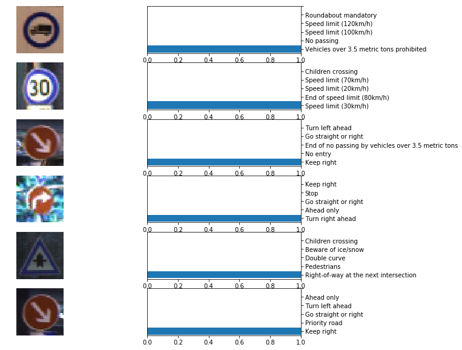

```python
### Print out the top five softmax probabilities for the predictions on the German traffic sign images found on the web.
### Feel free to use as many code cells as needed.
fig, axes = plt.subplots(6,2, figsize=(10,10))
for i, probs in enumerate(result[0]):
    axes[i, 0].imshow(new_images[i])
    axes[i, 0].axis('off')
    axes[i, 1].barh(probs, np.arange(5))
    axes[i, 1].yaxis.set_ticks_position('right')
    axes[i, 1].set_yticklabels(signname.SignName[result[1][i]].values)
    axes[i, 1].set_yticks(np.arange(6))
    axes[i, 1].set_xlim([0,1])
plt.savefig('./output_images/top5.jpg', bbox_inches="tight")
```